# Importing ASAP-seq data for analysis in Seurat/Signac

Oliver Knight

Compiled: June 07, 2023

# Introduction

Having finished processing our raw data, we are left with several outputs:

1. Sequenced DNA fragments which flank Tn5 insertion sites, as well as their corresponding single cell barcode (from `cellranger count`)
2. A count matrix of antibody capture and sample hashtags by single cell barcodes (from `asap-to-kite`)
3. A list of single barcodes and to which donor genotype they belong to (from `cellsnp-lite` and `vireo-snp`)
4. A list of barcodes which are estimated to be doublets based on the frequency of fragment overlap (from `AMULET`)
5. Count matrices for each nucleotide of mitochondrial DNA, by single cell barcodes, as well as other information (from `mgatk`).

Now, we are going to create our object which we can perform downstream analyses on. Roughly, this consists of 5 steps:

1. Importing raw peak data and creating a Seurat object with a Signac chromatin assay
2. Removing low quality cells and doublets called by genotyping, fragment overlap and hashtags
3. Calling fine peaks using a more specific peak-caller (`MACS2`)
4. Counting paired insertions at each peak
5. Adding mitochondrial genotyping data

# Importing raw count matrices

## Set variable directories

```r
Sys.setenv(RETICULATE_MINICONDA_PATH = "~/work/bin/miniconda3/")
Sys.setenv(PATH = paste("~/work/bin/miniconda3/envs/sc_python/lib/python3.11/site-packages/",
    Sys.getenv()["PATH"], sep = ":"))
Sys.setenv(TZ = "CET")

library(reticulate)
use_miniconda("~/work/bin/miniconda3/envs/sc_python/")

set.seed(56)
```

## Import R packages

```r
library(tidyverse)
library(Seurat)
library(SeuratWrappers)
library(SeuratDisk)
library(Signac)
library(GenomeInfoDb)
library(EnsDb.Hsapiens.v86)
library(harmony)
library(PICsnATAC)
library(Matrix)
library(pals)
library(showtext)
font_add_google("Roboto")
```

## Load annotations file

```r
# annotations <- GetGRangesFromEnsDb(ensdb = EnsDb.Hsapiens.v86)
# seqlevelsStyle(annotations) <- 'UCSC' genome(annotations) <- 'hg38'
# saveRDS(annotations, '~/group/work/ref/signac/hg38_ucsc_annotations.rds')
annotations <- readRDS("~/group/work/ref/signac/hg38_ucsc_annotations.rds")
```

## Read in peaks and filter for main chromosomes

First, we read in cellranger-called peaks. We will replace these later with those called by `MACS2`, but because we want to make sure that we are only calling from high-quality cells there, we use this to perform initial object creation and low-quality-cell removal.

```r
peaks <- c()
peaks$NK_CMVpos_exp3_libA <- read.table("../data/S3816_outs/NK_CMVpos_exp3_libA/outs/peaks.bed",
    col.names = c("chr", "start", "end")) %>%
    makeGRangesFromDataFrame()
peaks$NK_CMVpos_exp3_libB <- read.table("../data/S3816_outs/NK_CMVpos_exp3_libB/outs/peaks.bed",
    col.names = c("chr", "start", "end")) %>%
    makeGRangesFromDataFrame()
peaks$cellranger <- Reduce(union, peaks)
peaks$cellranger <- keepSeqlevels(peaks$cellranger, standardChromosomes(annotations)[1:24],
    pruning.mode = "coarse")
```

## Read in called cells, ATAC fragment files, and generate peak-by-cell matrix

We then import then names of cellranger-called cells, and the fragment files. The fragment files are independent of peaks called and are simply the flanking regions of DNA where Tn5 inserted it’s transposon sequence. Finally we create the count matrix.

```r
cells <- c()
cells$NK_CMVpos_exp3_libA <- readLines("../data/S3816_outs/NK_CMVpos_exp3_libA/outs/filtered_peak_bc_matrix/barcodes.tsv")
cells$NK_CMVpos_exp3_libB <- readLines("../data/S3816_outs/NK_CMVpos_exp3_libB/outs/filtered_peak_bc_matrix/barcodes.tsv")

fragments <- c()
fragments$NK_CMVpos_exp3_libA <- CreateFragmentObject("../data/S3816_outs/NK_CMVpos_exp3_libA/outs/fragments.tsv.gz",
    cells = cells[[1]])
```

```
## Computing hash
```

```r
fragments$NK_CMVpos_exp3_libB <- CreateFragmentObject("../data/S3816_outs/NK_CMVpos_exp3_libB/outs/fragments.tsv.gz",
    cells = cells[[2]])
```

```
## Computing hash
```

```r
matrices <- c()
matrices$NK_CMVpos_exp3_libA <- FeatureMatrix(fragments$NK_CMVpos_exp3_libA, peaks$cellranger,
    process_n = 10000)
```

```
## Extracting reads overlapping genomic regions
```

```r
matrices$NK_CMVpos_exp3_libB <- FeatureMatrix(fragments$NK_CMVpos_exp3_libB, peaks$cellranger,
    process_n = 10000)
```

```
## Extracting reads overlapping genomic regions
```

# Create Seurat objects

We now create a Seurat object which we can perform high-dimensional analysis on.

```r
alldata.atac <- c()
alldata.atac$NK_CMVpos_exp3_libA <- CreateChromatinAssay(matrices$NK_CMVpos_exp3_libA,
    fragments = fragments$NK_CMVpos_exp3_libA, features = peaks$cellranger) %>%
    CreateSeuratObject(assay = "ATAC", project = "NK_CMVpos_exp3_libA")
alldata.atac$NK_CMVpos_exp3_libB <- CreateChromatinAssay(matrices$NK_CMVpos_exp3_libB,
    fragments = fragments$NK_CMVpos_exp3_libB, features = peaks$cellranger) %>%
    CreateSeuratObject(assay = "ATAC", project = "NK_CMVpos_exp3_libB")
alldata.atac
```

```
## $NK_CMVpos_exp3_libA
## An object of class Seurat
## 111159 features across 6277 samples within 1 assay
## Active assay: ATAC (111159 features, 0 variable features)
##
## $NK_CMVpos_exp3_libB
## An object of class Seurat
## 111159 features across 6172 samples within 1 assay
## Active assay: ATAC (111159 features, 0 variable features)
```

```r
alldata.atac[[1]][["ATAC"]]
```

```
## ChromatinAssay data with 111159 features for 6277 cells
## Variable features: 0
## Genome:
## Annotation present: FALSE
## Motifs present: FALSE
## Fragment files: 1
```

This is the most raw ATAC object we will make, so it can be a good idea to save this here.

```bash
mkdir -p ../objects/raw
```

```r
saveRDS(alldata.atac, "../objects/raw/atac_object_raw.rds")
```

# Removing low quality cells

Our first low quality cell removal comes from lists we generated in the command line using `vireo` and `AMULET`. These contain heterotypic genotype doublets, and heterotypic/homotypic fragment overlap doublets. Steps included in importing these files include ensuring the order of cells in both the `Seurat` object and metadata lists are in the same order, so that when we add genotype information into the metadata slot they correspond to the correct cells. We then set the main identifier of the seurat object to the genotype of each cell.

```r
genotype_ids <- read.delim("../data/S3816_outs/NK_CMVpos_exp3_libA/genotype/donor_ids.tsv",
    header = T)
genotype_ids <- genotype_ids[genotype_ids$cell %in% colnames(alldata.atac[[1]]),
    ]
genotype_ids <- genotype_ids[order(match(genotype_ids$cell, colnames(alldata.atac[[1]]))),
    ]
name_index <- which(genotype_ids$donor_id == "unassigned")
genotype_ids$donor_id[name_index] <- "Unclear"
alldata.atac[[1]] <- AddMetaData(alldata.atac[[1]], metadata = genotype_ids$donor_id,
    col.name = "genotype")
alldata.atac[[1]] <- SetIdent(alldata.atac[[1]], value = "genotype")
alldata.atac[[1]] <- subset(alldata.atac[[1]], idents = "doublet", invert = T)
levels(alldata.atac[[1]]) <- c("donor0", "donor1", "Unclear")
table(alldata.atac[[1]]@active.ident)
```

```
##
## donor0 donor1
##   2732   3354
```

```r
genotype_ids <- read.delim("../data/S3816_outs/NK_CMVpos_exp3_libB/genotype/donor_ids.tsv",
    header = T)
genotype_ids <- genotype_ids[genotype_ids$cell %in% colnames(alldata.atac[[2]]),
    ]
genotype_ids <- genotype_ids[order(match(genotype_ids$cell, colnames(alldata.atac[[2]]))),
    ]
name_index <- which(genotype_ids$donor_id == "unassigned")
genotype_ids$donor_id[name_index] <- "Unclear"
alldata.atac[[2]] <- AddMetaData(alldata.atac[[2]], metadata = genotype_ids$donor_id,
    col.name = "genotype")
alldata.atac[[2]] <- SetIdent(alldata.atac[[2]], value = "genotype")
alldata.atac[[2]] <- subset(alldata.atac[[2]], idents = "doublet", invert = T)
levels(alldata.atac[[2]]) <- c("donor0", "donor1", "Unclear")
table(alldata.atac[[2]]@active.ident)
```

```
##
##  donor0  donor1 Unclear
##    2679    3318       2
```

Now we remove doublets called by `AMULET`, which are cells which have significantly more fragments than the background. Each cell should only have two fragments (one for each chromosome)

```r
amulet_doublets <- readLines("../data/S3816_outs/NK_CMVpos_exp3_libA/amulet/MultipletBarcodes_01.txt")
alldata.atac[[1]] <- subset(alldata.atac[[1]], cells = amulet_doublets, invert = T)

amulet_doublets <- readLines("../data/S3816_outs/NK_CMVpos_exp3_libB/amulet/MultipletBarcodes_01.txt")
alldata.atac[[2]] <- subset(alldata.atac[[2]], cells = amulet_doublets, invert = T)

rm(genotype_ids, amulet_doublets)
```

## Add hashtag data, and remove cells classed as doublets

We’ll add the antibody capture data we counted with our `ASAP-to-KITE` pipeline.

```r
folder <- "../data/S3816_outs/NK_CMVpos_exp3_libA/adt/"
adt <- t(readMM(file = paste0(folder, "output.mtx")))
features <- readLines(paste0(folder, "output.genes.txt"))
barcodes <- readLines(paste0(folder, "output.barcodes.txt"))
colnames(adt) <- barcodes %>%
    paste0("-1")
rownames(adt) <- features
adt <- as(adt, "CsparseMatrix")
adt <- CreateSeuratObject(adt, assay = "ADT") %>%
    subset(cells = colnames(alldata.atac[[1]]))
alldata.atac[[1]] <- subset(alldata.atac[[1]], cells = colnames(adt))
alldata.atac[[1]][["ADT"]] <- subset(adt@assays$ADT, features = rownames(adt)[1:19])
alldata.atac[[1]][["HTO"]] <- subset(adt@assays$ADT, features = rownames(adt)[20:21])
folder <- "../data/S3816_outs/NK_CMVpos_exp3_libB/adt/"
adt <- t(readMM(file = paste0(folder, "output.mtx")))
features <- readLines(paste0(folder, "output.genes.txt"))
barcodes <- readLines(paste0(folder, "output.barcodes.txt"))
colnames(adt) <- barcodes %>%
    paste0("-1")
rownames(adt) <- features
adt <- as(adt, "CsparseMatrix")
adt <- CreateSeuratObject(adt, assay = "ADT") %>%
    subset(cells = colnames(alldata.atac[[2]]))
alldata.atac[[2]] <- subset(alldata.atac[[2]], cells = colnames(adt))
alldata.atac[[2]][["ADT"]] <- subset(adt@assays$ADT, features = rownames(adt)[1:19])
alldata.atac[[2]][["HTO"]] <- subset(adt@assays$ADT, features = rownames(adt)[20:21])
rm(folder, adt, features, barcodes)
```

## Normalise antibody capture data

We next normalise each surface protein and hashtag data with a centre log ratio.

```r
for (i in 1:length(alldata.atac)) {
    print(paste0("Normalising hashtag data for sample ", i, ", ", names(alldata.atac[i])))
    DefaultAssay(alldata.atac[[i]]) <- "ADT"
    alldata.atac[[i]] <- NormalizeData(alldata.atac[[i]], assay = "ADT", normalization.method = "CLR")
    DefaultAssay(alldata.atac[[i]]) <- "HTO"
    alldata.atac[[i]] <- NormalizeData(alldata.atac[[i]], assay = "HTO", normalization.method = "CLR")
}
```

```
## [1] "Normalising hashtag data for sample 1, NK_CMVpos_exp3_libA"
```

```
## Normalizing across features
## Normalizing across features
```

```
## [1] "Normalising hashtag data for sample 2, NK_CMVpos_exp3_libB"
```

```
## Normalizing across features
## Normalizing across features
```

## Set expression limits, remove doublets, annotate cells

Finally for doublet removal, we visualise our hashtag scatter before setting cutoffs and removing heterotypic doublets. We then add on to our genotype data our confident hashtag data, to be absolutely sure we have assigned our cells to the right donors.

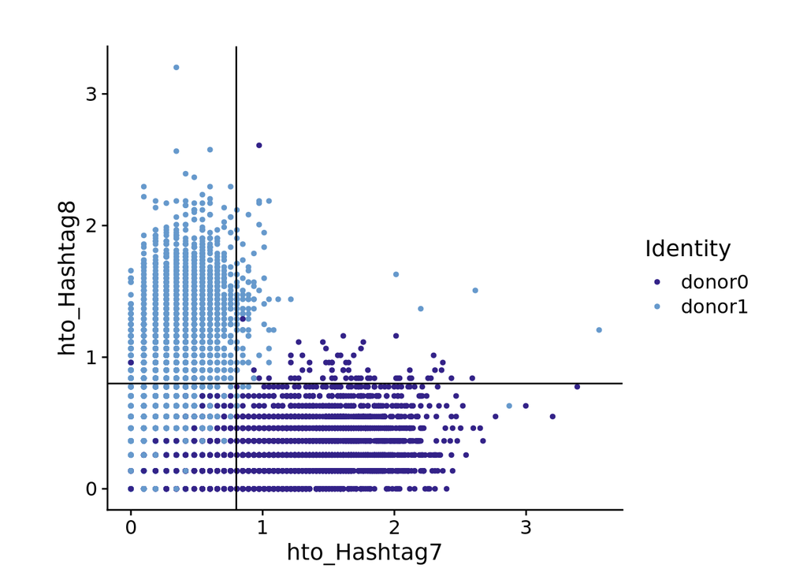

```r
FeatureScatter(alldata.atac[[1]], "hto_Hashtag7", "hto_Hashtag8", cols = tol(), plot.cor = F) &
    geom_vline(xintercept = 0.8) & geom_hline(yintercept = 0.8) & coord_fixed()
```

```r
hashtag7_cutoff = 0.8
hashtag8_cutoff = 0.8

selected <- WhichCells(alldata.atac[[1]], expression = hto_Hashtag7 > hashtag7_cutoff &
    hto_Hashtag8 > hashtag8_cutoff)
alldata.atac[[1]] <- subset(alldata.atac[[1]], cells = selected, invert = T)

alldata.atac[[1]]$donor <- alldata.atac[[1]]$genotype
selected <- WhichCells(alldata.atac[[1]], expression = hto_Hashtag7 > hashtag7_cutoff &
    hto_Hashtag8 < hashtag8_cutoff)
alldata.atac[[1]]$donor <- ifelse(colnames(alldata.atac[[1]]) %in% selected, "Donor 1",
    alldata.atac[[1]]$donor)
selected <- WhichCells(alldata.atac[[1]], expression = hto_Hashtag7 < hashtag7_cutoff &
    hto_Hashtag8 > hashtag8_cutoff)
alldata.atac[[1]]$donor <- ifelse(colnames(alldata.atac[[1]]) %in% selected, "Donor 2",
    alldata.atac[[1]]$donor)
alldata.atac[[1]]$donor[alldata.atac[[1]]$genotype == "donor0"] <- "Donor 1"
alldata.atac[[1]]$donor[alldata.atac[[1]]$genotype == "donor1"] <- "Donor 2"
alldata.atac[[1]]$donor[alldata.atac[[1]]$genotype == "Unclear"] <- "Unclear"

selected <- WhichCells(alldata.atac[[1]], expression = hto_Hashtag7 > hashtag7_cutoff &
    hto_Hashtag8 < hashtag8_cutoff)
alldata.atac[[1]]$donor <- ifelse(colnames(alldata.atac[[1]]) %in% selected, "Donor 1",
    alldata.atac[[1]]$donor)
selected <- WhichCells(alldata.atac[[1]], expression = hto_Hashtag7 < hashtag7_cutoff &
    hto_Hashtag8 > hashtag8_cutoff)
alldata.atac[[1]]$donor <- ifelse(colnames(alldata.atac[[1]]) %in% selected, "Donor 2",
    alldata.atac[[1]]$donor)

alldata.atac[[1]] <- SetIdent(alldata.atac[[1]], value = "donor")
levels(alldata.atac[[1]]) <- c("Donor 1", "Donor 2", "Unclear")
table(alldata.atac[[1]]@active.ident)
```

```
##
## Donor 1 Donor 2
##    2555    3056
```

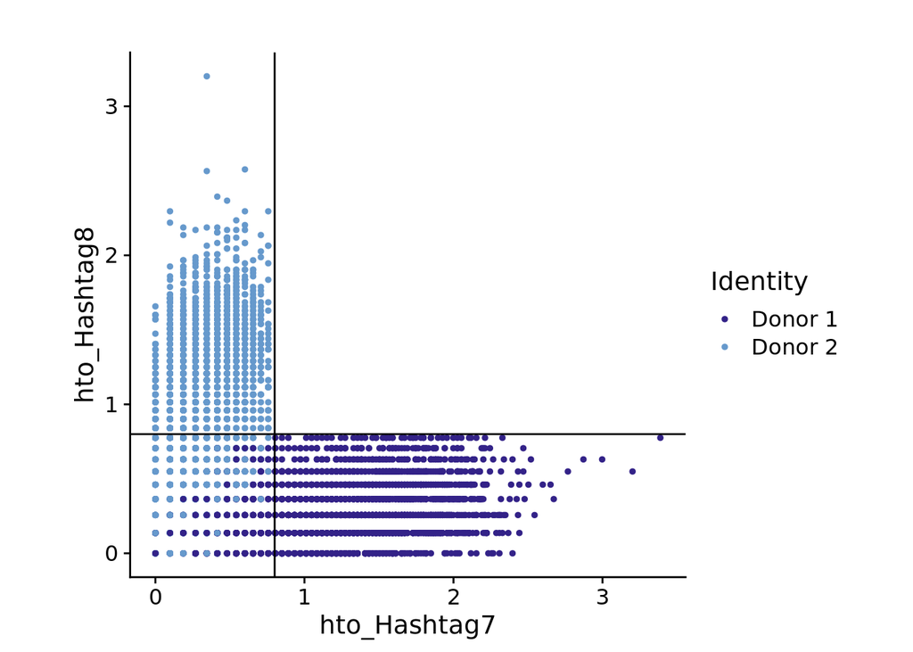

```r
FeatureScatter(alldata.atac[[1]], "hto_Hashtag7", "hto_Hashtag8", cols = tol(), plot.cor = F) &
    geom_vline(xintercept = 0.8) & geom_hline(yintercept = 0.8) & coord_fixed()
```

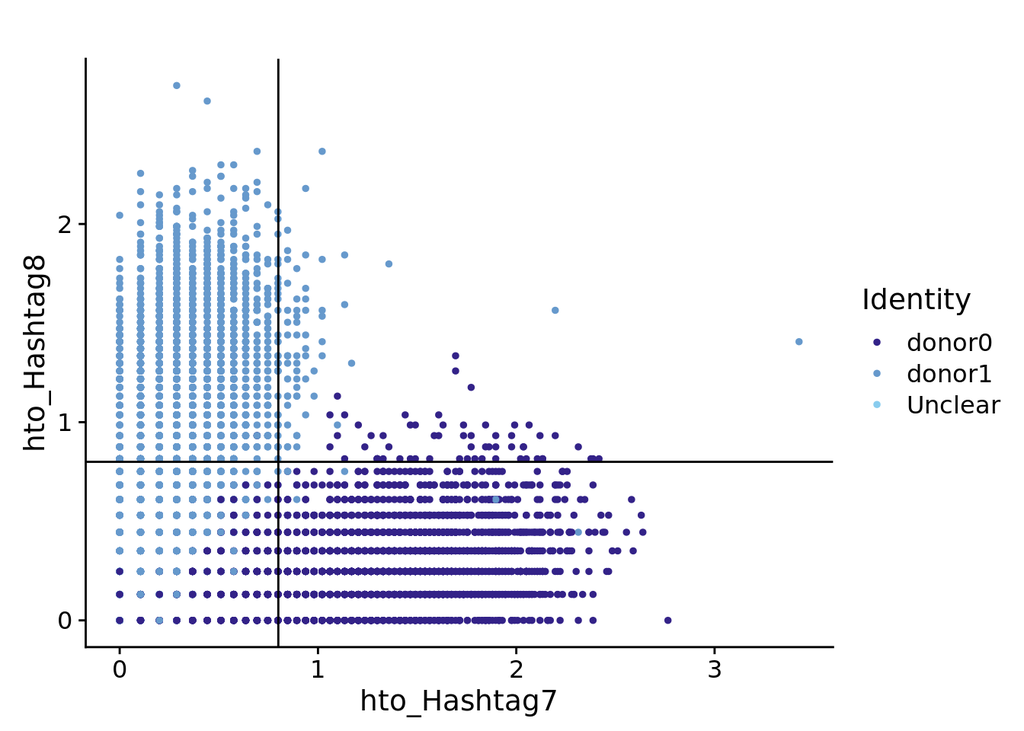

```r
rm(hashtag7_cutoff, hashtag8_cutoff, selected)

FeatureScatter(alldata.atac[[2]], "hto_Hashtag7", "hto_Hashtag8", cols = tol(), plot.cor = F) &
    geom_vline(xintercept = 0.8) & geom_hline(yintercept = 0.8) & coord_fixed()
```

```r
hashtag7_cutoff = 0.8
hashtag8_cutoff = 0.8

selected <- WhichCells(alldata.atac[[2]], expression = hto_Hashtag7 > hashtag7_cutoff &
    hto_Hashtag8 > hashtag8_cutoff)
alldata.atac[[2]] <- subset(alldata.atac[[2]], cells = selected, invert = T)

alldata.atac[[2]]$donor <- alldata.atac[[2]]$genotype
selected <- WhichCells(alldata.atac[[2]], expression = hto_Hashtag7 > hashtag7_cutoff &
    hto_Hashtag8 < hashtag8_cutoff)
alldata.atac[[2]]$donor <- ifelse(colnames(alldata.atac[[2]]) %in% selected, "Donor 1",
    alldata.atac[[2]]$donor)
selected <- WhichCells(alldata.atac[[2]], expression = hto_Hashtag7 < hashtag7_cutoff &
    hto_Hashtag8 > hashtag8_cutoff)
alldata.atac[[2]]$donor <- ifelse(colnames(alldata.atac[[2]]) %in% selected, "Donor 2",
    alldata.atac[[2]]$donor)
alldata.atac[[2]]$donor[alldata.atac[[2]]$genotype == "donor0"] <- "Donor 1"
alldata.atac[[2]]$donor[alldata.atac[[2]]$genotype == "donor1"] <- "Donor 2"
alldata.atac[[2]]$donor[alldata.atac[[2]]$genotype == "Unclear"] <- "Unclear"

selected <- WhichCells(alldata.atac[[2]], expression = hto_Hashtag7 > hashtag7_cutoff &
    hto_Hashtag8 < hashtag8_cutoff)
alldata.atac[[2]]$donor <- ifelse(colnames(alldata.atac[[2]]) %in% selected, "Donor 1",
    alldata.atac[[2]]$donor)
selected <- WhichCells(alldata.atac[[2]], expression = hto_Hashtag7 < hashtag7_cutoff &
    hto_Hashtag8 > hashtag8_cutoff)
alldata.atac[[2]]$donor <- ifelse(colnames(alldata.atac[[2]]) %in% selected, "Donor 2",
    alldata.atac[[2]]$donor)

alldata.atac[[2]] <- SetIdent(alldata.atac[[2]], value = "donor")
levels(alldata.atac[[2]]) <- c("Donor 1", "Donor 2", "Unclear")
table(alldata.atac[[2]]@active.ident)
```

```
##
## Donor 1 Donor 2 Unclear
##    2493    3070       2
```

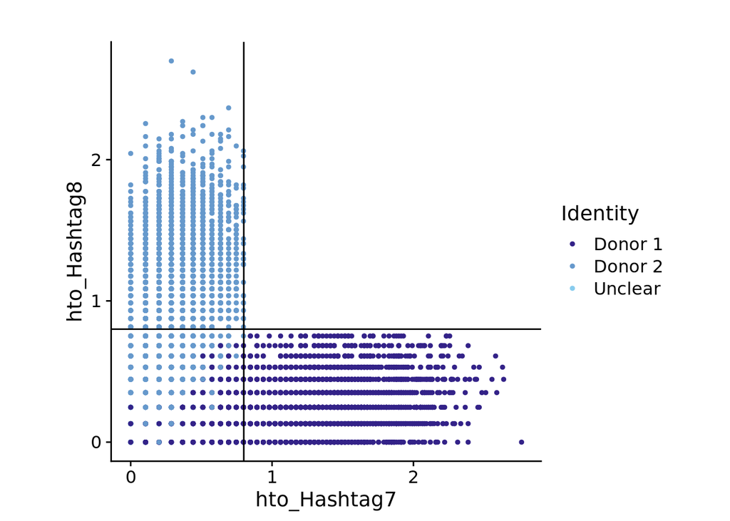

```r
FeatureScatter(alldata.atac[[2]], "hto_Hashtag7", "hto_Hashtag8", cols = tol(), plot.cor = F) &
    geom_vline(xintercept = 0.8) & geom_hline(yintercept = 0.8) & coord_fixed()
```

```r
rm(hashtag7_cutoff, hashtag8_cutoff, selected)
```

## Calculate QC metrics of each cell

Next, we calculate two quality control metrics from the fragment files:

1. The nucleosome signal, which is a visual assessment of the periodicity of reads aligned to the genome. The presence of clear nucleosome banding indicates successful fragmentation and transposition, reflecting the enrichment of accessible chromatin regions.
2. The TSS enrichment score, which measures the enrichment of ATAC-seq reads around transcriptional start sites. Accessible chromatin regions near TSSs are expected to have a higher density of reads compared to other genomic regions.

```r
for (i in 1:length(alldata.atac)) {
    print(paste0("Performing QC of ", names(alldata.atac[i])))
    DefaultAssay(alldata.atac[[i]]) <- "ATAC"
    Annotation(alldata.atac[[i]]) <- annotations
    alldata.atac[[i]] <- NucleosomeSignal(alldata.atac[[i]], verbose = F)
    alldata.atac[[i]] <- TSSEnrichment(alldata.atac[[i]], fast = FALSE, process_n = 10000,
        verbose = F)
}
```

```
## [1] "Performing QC of NK_CMVpos_exp3_libA"
## [1] "Performing QC of NK_CMVpos_exp3_libB"
```

## Visualise QC metrics of each cell and remove low quality cells

We visualise the TSS with density plots to understand where most cells lie, and remove those of low quality.

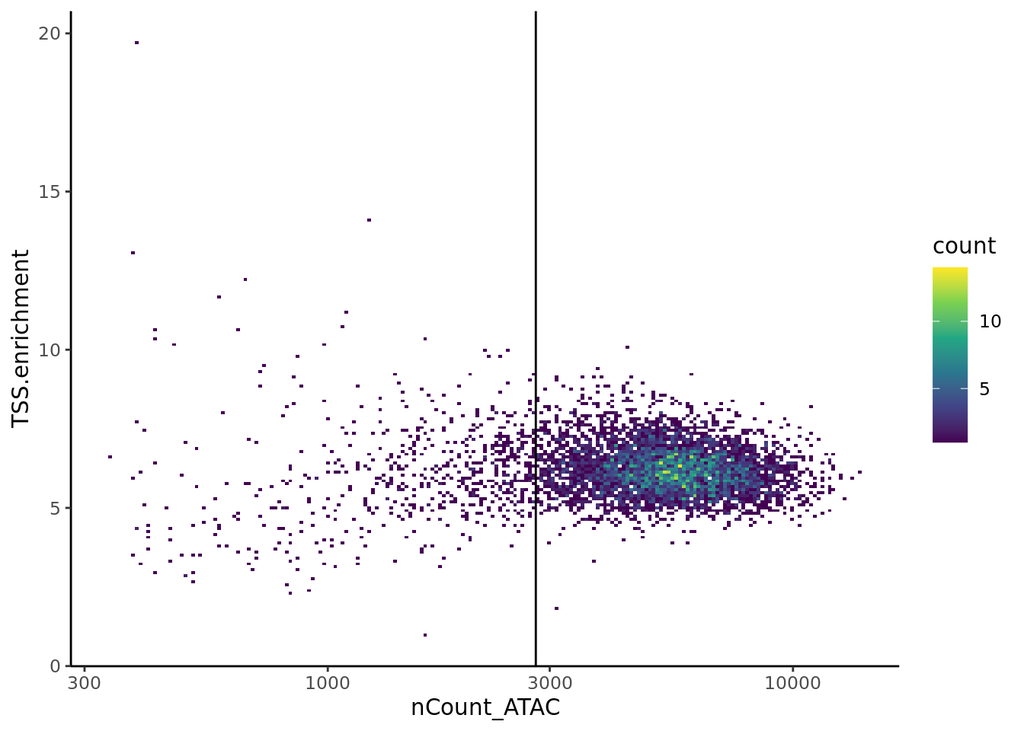

```r
ggplot(alldata.atac[[1]]@meta.data, aes(nCount_ATAC, TSS.enrichment)) + geom_bin2d(bins = 200) +
    theme_classic() + scale_fill_continuous(type = "viridis") + scale_x_log10() &
    geom_vline(xintercept = 2800)
```

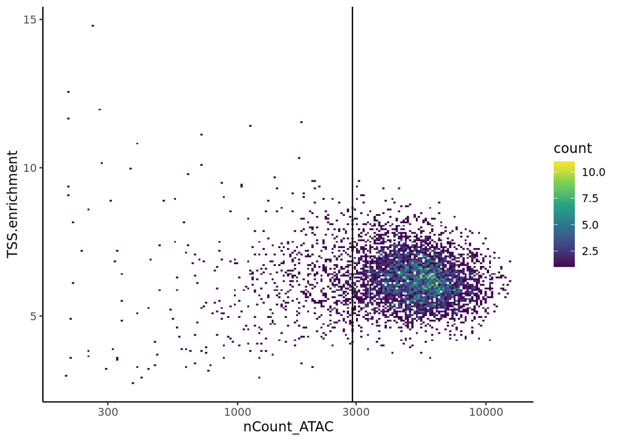

```r
high_quality <- WhichCells(alldata.atac[[1]], expression = nCount_ATAC >= 2800)
alldata.atac[[1]] <- subset(alldata.atac[[1]], cells = high_quality)

ggplot(alldata.atac[[2]]@meta.data, aes(nCount_ATAC, TSS.enrichment)) + geom_bin2d(bins = 200) +
    theme_classic() + scale_fill_continuous(type = "viridis") + scale_x_log10() &
    geom_vline(xintercept = 2900)
```

```r
high_quality <- WhichCells(alldata.atac[[2]], expression = nCount_ATAC > 2800)
alldata.atac[[2]] <- subset(alldata.atac[[2]], cells = high_quality)

rm(high_quality)
```

## Perform temporary clustering for `MACS2` peak calling

We now perform a temporary dimensionality reduction in order to cluster our cells. We do this as we will perform peak-calling with `MACS2`, which is more fine with calling peaks. As different celltypes have different regions of openly accessibly chromatin, we need clustering information to be able to call peaks which may get lost by calling peaks at a bulk level. We perform this clustering on a temporary object, `temp`, and then overlay annotated clusters back onto our original objects.

```r
for (i in 1:length(alldata.atac)) {
    print(paste0("Performing dimensionality reduction of ", names(alldata.atac[i])))
    temp <- alldata.atac[[i]]
    temp <- RunTFIDF(temp, verbose = F) %>%
        FindTopFeatures(verbose = F) %>%
        RunSVD(reduction.name = "lsi_atac") %>%
        FindNeighbors(reduction = "lsi_atac", dims = 2:11, k.param = 30, verbose = F) %>%
        FindClusters(graph.name = "ATAC_snn", resolution = 0.1, algorithm = 3, group.singletons = T,
            verbose = F)
    alldata.atac[[i]]$coarse_clusters <- temp$seurat_clusters
}
```

```
## [1] "Performing dimensionality reduction of NK_CMVpos_exp3_libA"
```

```
## Running SVD
```

```
## Scaling cell embeddings
```

```
## [1] "Performing dimensionality reduction of NK_CMVpos_exp3_libB"
```

```
## Running SVD
## Scaling cell embeddings
```

## Perform `MACS2` peak calling

```r
peaks$macs2.NK_CMVpos_exp3_libA <- CallPeaks(alldata.atac[[1]], assay = "ATAC", group.by = "coarse_clusters",
    macs2.path = "~/work/bin/miniconda3/envs/sc_python/bin/macs2", verbose = F)
peaks$macs2.NK_CMVpos_exp3_libB <- CallPeaks(alldata.atac[[2]], assay = "ATAC", group.by = "coarse_clusters",
    macs2.path = "~/work/bin/miniconda3/envs/sc_python/bin/macs2", verbose = F)
peaks$macs2.total <- reduce(x = c(peaks$macs2.NK_CMVpos_exp3_libA, peaks$macs2.NK_CMVpos_exp3_libB))
peaks$macs2.total <- keepSeqlevels(peaks$macs2.total, standardChromosomes(annotations)[1:24],
    pruning.mode = "coarse")
```

```r
saveRDS(peaks, "../objects/raw/atac_peaks.rds")
peaks <- readRDS("../objects/raw/atac_peaks.rds")
```

## Count paired insertions

To understand why I like to use paired-insertion-counting (PIC), I would suggest reading this pre-print [‘Is single nucleus ATAC-seq accessibility a qualitative or quantitative measurement?’](https://www.biorxiv.org/content/10.1101/2022.04.20.488960v1) This performs PIC and replaces the original matrix with one containing the `MACS2`-called peaks, and subsequently normalises our matrix for dimensionality reduction and beyond.

```r
# create macs2 assay and remove original atac one
for (i in 1:length(alldata.atac)) {
    print(paste0("Counting paired insertions for ", names(alldata.atac[i])))
    counts <- PIC_counting(colnames(alldata.atac[[i]]), alldata.atac[[i]]@assays$ATAC@fragments[[1]]@path,
        peaks$macs2.total)
    alldata.atac[[i]][["ATAC"]] <- CreateChromatinAssay(counts = counts, sep = c(":",
        "-"), fragments = alldata.atac[[i]]@assays$ATAC@fragments[[1]]@path)
    Annotation(alldata.atac[[i]]) <- annotations
    alldata.atac[[i]] <- RunTFIDF(alldata.atac[[i]])
}
```

```
## [1] "Counting paired insertions for NK_CMVpos_exp3_libA"
## [1] "all fragment data loaded"
## [1] "computing peak vector for each cell"
## ================================================================================
```

```
## Computing hash
```

```
## Performing TF-IDF normalization
```

```
## [1] "Counting paired insertions for NK_CMVpos_exp3_libB"
## [1] "all fragment data loaded"
## [1] "computing peak vector for each cell"
## ================================================================================
```

```
## Computing hash
## Performing TF-IDF normalization
```

```r
rm(peaks, cells, fragments, matrices, counts, annotations, i, temp, features)
```

## Save objects

```r
saveRDS(alldata.atac, "../objects/raw/atac_filtered.rds")
```